본 포스트는 https://medium.com/%5C@hablo/a-beginner-guide-to-t-test-and-anova-analysis-of-variance-in-r-programming-d65944a97ce1 를 참조하여 작성되었음.

## ANOVA(ANalysis of VAriance) : 분산 분석

분산 분석(Analysis Of VAriance)은 둘 이상의 모집단 평균이 다른지 여부를 확인하기 위한 통계적 검정이다. 결국 둘 이상의 그룹을 비교하여 유의미한 차이가 있는지 확인하는 데 사용된다.

사실상,

- Student t-test 는 2개의 그룹간의 평균을 비교하는 것이고,
- ANOVA는 2개 이상의 그룹을 비교하는데 3개 이상의 그룹간의 평균의 비교에 많이 사용된다.

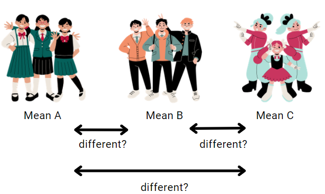

https://medium.com/%5C@hablo/a-beginner-guide-to-t-test-and-anova-analysis-of-variance-in-r-programming-d65944a97ce1

ANOVA는 각 표본 그룹이 정규 분포를 따르고 분산이 동일하며 독립적이라는 가정이 만족되어야 한다.

### 일원 분산 분석(One Way ANOVA)

일원 분산 분석(One Way ANOVA) 두 개 이상의 그룹간의 평균의 차이를 분석하는 데 사용된다.

자동차의 연비에 대한 예를 살펴보자. 종속 변수(DV)는 연료 갤런(mpg)당 자동차가 이동할 수 있는 마일이고 독립 변수(IV)는 자동차의 브랜드라고 가정한다. 다음과 같이 세개의 브랜드 자동차간의 평균이 유의하게 다른지 테스트하기 위해 분산 분석을 사용한다.

| A | B | C |
| --- | --- | --- |
| 19 | 28 | 20 |
| 17 | 30 | 23 |
| 16 | 32 | 25 |
| 20 | 33 | 24 |
| 17 | 31 | 21 |
| 19 | 27 | 22 |
| 15 | 29 | 24 |
| 21 | 30 | 21 |

위 데이터를 R로 불러들인다.

```r
car <- c(rep(c('A', 'B', 'C'), each = 8))
mpg <- c(19, 17, 16, 20, 17, 19, 15, 21,
         28, 30, 32, 33, 31, 27, 29, 30,
         20, 23, 25, 24, 21, 22, 24, 21)

mpgData <- data.frame(car, mpg)
mpgData
```

```
##    car mpg
## 1    A  19
## 2    A  17
## 3    A  16
## 4    A  20
## 5    A  17
## 6    A  19
## 7    A  15
## 8    A  21
## 9    B  28
## 10   B  30
## 11   B  32
## 12   B  33
## 13   B  31
## 14   B  27
## 15   B  29
## 16   B  30
## 17   C  20
## 18   C  23
## 19   C  25
## 20   C  24
## 21   C  21
## 22   C  22
## 23   C  24
## 24   C  21
```

$H0 : \mu(A) = \mu(B) = \mu(C)$

$Ha : \text{최소 두개의 평균은 다르다(at least two means are different)}$

ANOVA를 실행하기 위해서는 `aov()`를 사용할 수 있다.

```r
model <- aov(mpg ~ car, data = mpgData)
summary(model)
```

```
##             Df Sum Sq Mean Sq F value  Pr(>F)
## car          2    588  294.00   77.17 2.1e-10 ***
## Residuals   21     80    3.81
## ---
## Signif. codes:  0 '***' 0.001 '**' 0.01 '*' 0.05 '.' 0.1 ' ' 1
```

위의 결과를 보면 F 값(F value)는 77.17, p-value는 매우 작은 값으로 0.05보다 작게 나타나고 있다. 이로 인해 세 그룹의 평균간의 차이가 없다는 귀무 가설을 기각할 수 있고, 최소 두개의 평균은 다르다는 대립 가설을 채택한다.

그렇다면 각각의 평균은 어떻게 다르고 어떤 평균간의 차이가 의미가 있을지를 알수 있는가? 이는 `TukeyHSD()`를 사용한다.

```r
TukeyHSD(model)
```

```
##   Tukey multiple comparisons of means
##     95% family-wise confidence level
##
## Fit: aov(formula = mpg ~ car, data = mpgData)
##
## $car
##     diff       lwr       upr     p adj
## B-A 12.0  9.540175 14.459825 0.0000000
## C-A  4.5  2.040175  6.959825 0.0004259
## C-B -7.5 -9.959825 -5.040175 0.0000005
```

위의 결과를 보면 P-Value인 ‘p adj’ 값이 모두 0.05보다 작기 때문에 B와 A, C와 A, C와 B 간의 평균의 차이가 모두 유의미하게 차이가 있다는 것을 알 수 있는데 각각의 평균의 차이가 C-A가 4.5인 반면 B-A가 12.0으로 더 크게 나타나고 있다.

마지막으로 중요한 것은 신뢰 구간에 값 0이 포함되어 있지 않으면 두 변수의 평균 간에 상당한 차이가 있다는 것이다.

예를 들어 B-A의 상한(upr)은 14.45이고 하한(lwr)은 9.54로 그 사이에 0을 포함하고 있지 않다.

### 이원 분산 분석(Two Way ANOVA)

이원 분산 분석은 하나의 종속 변수와 두개의 독립변수간의 상호작용이 영향을 미치는지를 알아보기 위해 사용된다. DV의 두 IV 사이에 상호 작용이 있는지 연구하고 싶기 때문에 두 개의 독립 변수(IV)가 조합되어 종속 변수(DV)에 어떤 영향을 미치는지 분석하고자 할 때 적용됩니다.

예를 들어, 위에서 언급한 자동차의 mpg 값이 고속도로에서 운전할 때와 시내에서 운전할 때 다른지 알고 싶을때 사용할 수 있다.

|  | A | B | C |
| --- | --- | --- | --- |
| city | 14 | 28 | 20 |
| city | 12 | 26 | 21 |
| city | 15 | 26 | 19 |
| highway | 19 | 33 | 27 |
| highway | 18 | 32 | 26 |
| highway | 19 | 33 | 24 |

이원 분산 분석을 위해 다음과 같이 데이터를 만든다.

```r
where <- c(rep('city', 9), rep('highway', 9))
brand <- c(rep(c('A', 'B', 'C'), each = 3))
mpg2 <- c(14, 12, 15,
          28, 26, 26,
          20, 21, 19,
          19, 18, 19,
          33, 32, 33,
          27, 26, 24)

twoway <- data.frame(where, brand, mpg2)
twoway
```

```
##      where brand mpg2
## 1     city     A   14
## 2     city     A   12
## 3     city     A   15
## 4     city     B   28
## 5     city     B   26
## 6     city     B   26
## 7     city     C   20
## 8     city     C   21
## 9     city     C   19
## 10 highway     A   19
## 11 highway     A   18
## 12 highway     A   19
## 13 highway     B   33
## 14 highway     B   32
## 15 highway     B   33
## 16 highway     C   27
## 17 highway     C   26
## 18 highway     C   24
```

이원 분산 분석에는 세 가지의 가설들이 검정되어야 한다.

첫 번째 가설은 다음과 같다.

$H0 : \mu(A) = \mu(B) = \mu(C)$

$Ha : \text{최소 두개의 평균이 다르다(At least two means are different)}$

```r
model1 <- aov(mpg2 ~ where + brand + where*brand, data = twoway)

summary(model1)
```

```
##             Df Sum Sq Mean Sq F value   Pr(>F)
## where        1  138.9  138.89 108.696 2.28e-07 ***
## brand        2  546.8  273.39 213.957 4.12e-10 ***
## where:brand  2    0.8    0.39   0.304    0.743
## Residuals   12   15.3    1.28
## ---
## Signif. codes:  0 '***' 0.001 '**' 0.01 '*' 0.05 '.' 0.1 ' ' 1
```

위의 결과에서 p brand의 p-value는 0.05보다 작기 때문에 brand간의 평균은 최소 두개의 평균이 다르다는 대립 가설을 채택한다.

두 번째 가설은

$H0 : \mu(city) = \mu(highway)$

$Ha : \mu(city) \ne \mu(highway)$

앞선 `aov()`의 결과에서 brand 변수와 유사하게, 차를 운전하는 장소를 의미하는 where 변수는 p-값이 0.05(= 2.28e-07)보다 작기 때문에 장소에 따른 평균 차이가 같지 않다는 대립 가설을 채택한다.

마지막으로 다음의 가설을 검정한다.

$H0 : \text{brand와 where간의 상호작용이 없다}$

$Ha : \text{brand와 where간의 상호작용이 있다}$

앞선 `aov()`의 결과에서 where:brand가 where에 따른 brand의 상호작용에 대한 변수를 말한다. 이 변수의 p value가 0.743으로 매우 큰 p-value가 나온다. 이로 인해 귀무가설인 ’brand와 where 간의 상호작용이 없다’는 귀무가설을 기각할 수 없고 brand와 where간의 상호작용이 있다는 가설에 대한 충분한 증거가 없다.

이를 앞에서 사용했던 `TukeyHSD()`를 사용해 상세히 살펴본다. Tukey 테스트는 차이가 가장 많이 발생하는 부분과 특정 그룹의 평균이 다른 부분을 파악하는 데 도움이 된다.

```r
TukeyHSD(model1)
```

```
##   Tukey multiple comparisons of means
##     95% family-wise confidence level
##
## Fit: aov(formula = mpg2 ~ where + brand + where * brand, data = twoway)
##
## $where
##                  diff      lwr     upr p adj
## highway-city 5.555556 4.394531 6.71658 2e-07
##
## $brand
##          diff       lwr       upr p adj
## B-A 13.500000 11.758872 15.241128 0e+00
## C-A  6.666667  4.925539  8.407795 8e-07
## C-B -6.833333 -8.574461 -5.092205 6e-07
##
## $`where:brand`
##                           diff        lwr       upr     p adj
## highway:A-city:A      5.000000   1.899856  8.100144 0.0016653
## city:B-city:A        13.000000   9.899856 16.100144 0.0000001
## highway:B-city:A     19.000000  15.899856 22.100144 0.0000000
## city:C-city:A         6.333333   3.233190  9.433477 0.0001960
## highway:C-city:A     12.000000   8.899856 15.100144 0.0000002
## city:B-highway:A      8.000000   4.899856 11.100144 0.0000190
## highway:B-highway:A  14.000000  10.899856 17.100144 0.0000000
## city:C-highway:A      1.333333  -1.766810  4.433477 0.7020060
## highway:C-highway:A   7.000000   3.899856 10.100144 0.0000738
## highway:B-city:B      6.000000   2.899856  9.100144 0.0003268
## city:C-city:B        -6.666667  -9.766810 -3.566523 0.0001194
## highway:C-city:B     -1.000000  -4.100144  2.100144 0.8788715
## city:C-highway:B    -12.666667 -15.766810 -9.566523 0.0000001
## highway:C-highway:B  -7.000000 -10.100144 -3.899856 0.0000738
## highway:C-city:C      5.666667   2.566523  8.766810 0.0005535
```

이 결과를 시각화하면 더 알아보기가 편하다.

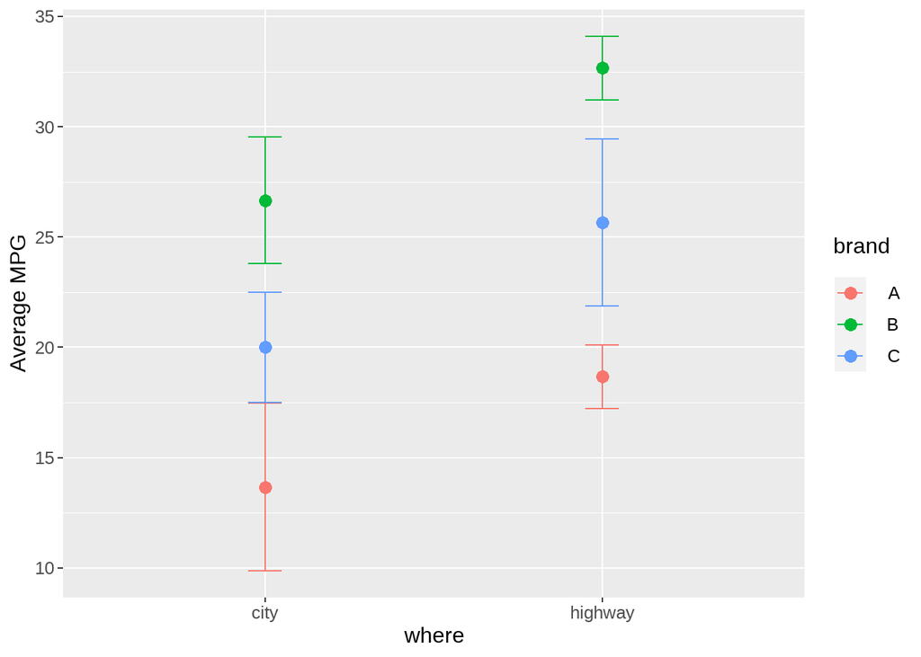

```r
twoway |>
  group_by(where, brand) |>
  summarise(ave = mean(mpg2), se = sd(mpg2) / sqrt(length(mpg2)), tstar = qt(1-0.05/2, length(mpg2)-1)) |>
  ggplot(aes(x = where, y = ave)) +
  geom_point(aes(color = brand), size = 3) +
  geom_errorbar(aes(ymin = ave -se * tstar, ymax = ave + se * tstar, color = brand), width = 0.1) +
  ylab('Average MPG')
```